# Assignment_1_6783_netID

### Group Members:

[output not shown]

#### Part 1-1: Generate Data

First generate the 20 centers from two-dimensional normal and randomly split them into two classes of 10. You can use any mean and covariance structure. You should not regenerate the centers. Use these 20 centers throughout this simulation study.

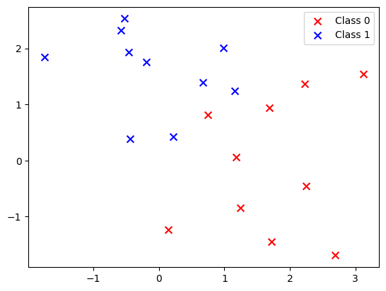

```python
import numpy as np
import matplotlib.pyplot as plt
from sklearn.neighbors import KNeighborsClassifier as knn
from sklearn.metrics import confusion_matrix
from sklearn import linear_model as lm
import scipy.stats as ss

np.random.seed(100)

csize = 10 #每個類別有 10 個點
p = 2
s = 1      # sd for generating x
m1 = [1,0]
m0 = [0,1]

mean = np.array([0, 0])
cov = np.array([m1,m0])

distr = ss.multivariate_normal(cov = cov, mean = mean)

m1 = distr.rvs(size = csize) + np.array([0, 1.5]) #確保中心點不會重新生成: rvs => generates random deviates
m0 = distr.rvs(size = csize) + np.array([1.5, 0])

plt.scatter(m0[:,0], m0[:,1], marker = 'x', s = 50, c = "red", label='Class 0') ##([x 座標值],[y 座標值],marker=標籤樣式,s=標籤面積,c=color ,label)
plt.scatter(m1[:,0], m1[:,1], marker = 'x', s = 50, c = "blue", label='Class 1')

plt.legend()
plt.show()
```

#### Part 1-2

Given the 20 centers, generate a training sample of size 200 (100 from each class) and a test sample of size 10,000 (5,000 from each class).

```python
def helper(n, centers, cov):
    # 隨機分配 n 個樣本到中心點
    num_centers = len(centers) // 2  # 假設中心點數量是每個類別的兩倍
    ids = np.random.randint(num_centers, size = n)

    # 生成數據
    data = np.random.multivariate_normal(centers[ids[0]], cov)

    # 生成標籤
    y = np.concatenate(([1]*n, [0]*n))

    return (data, y)


centers = np.array([[0, 2], [2, 0]])  # 簡化為兩個中心點
cov = np.array([[1, 0], [0, 1]])  # 簡化為單位協方差矩陣

training_sample = 100 #generate a training sample of size 200 (100 from each class)
training_set_id0 = np.random.randint(0, csize, size=training_sample)
training_set_id1 = np.random.randint(0, csize, size=training_sample)
(traindata, ytrain) = helper(training_sample, centers, cov)
X_training = np.random.normal(size=(2 * training_sample, p)) * s + np.vstack((m0[training_set_id0], m1[training_set_id1]))
Y_training = np.array([0]*training_sample  + [1]*training_sample)

test_sample = 5000 #generate a test sample of size 10,000 (5,000 from each class).
testing_set_id0 = np.random.randint(0, csize, size=test_sample)
testing_set_id1 = np.random.randint(0, csize, size=test_sample)
(testdata, ytest) = helper(test_sample, centers, cov)
X_testing = np.random.normal(size=(2 * test_sample, p)) * s + np.vstack((m0[testing_set_id0], m1[testing_set_id1]))
Y_testing = np.array([0]*test_sample  + [1]*test_sample)
```

#### Part 1-3

Produce a scatter plot of the training data:

assign different colors to the two classes of data points;

overlay the 20 centers on this scatter plot, using a distinguishing marker (e.g., a star or a different

shape) and color them according to their respective class.

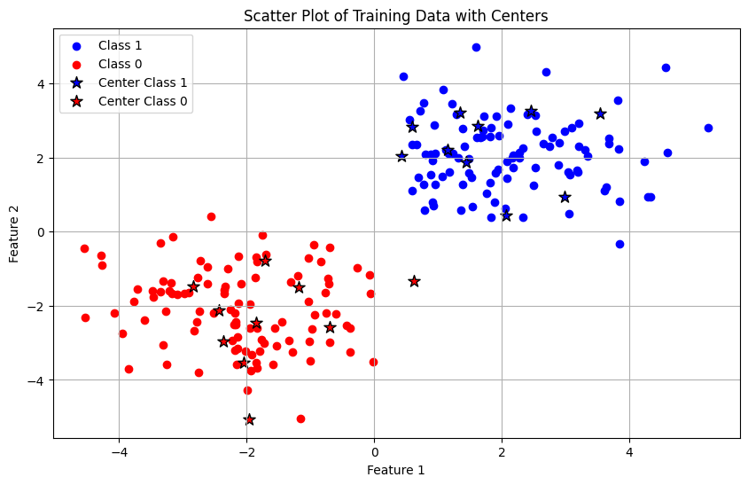

```python
class1_data = np.random.multivariate_normal(mean=[2, 2], cov=[[1, 0], [0, 1]], size=100)
class0_data = np.random.multivariate_normal(mean=[-2, -2], cov=[[1, 0], [0, 1]], size=100)

# 假設 20 個中心點
class1_centers = np.random.multivariate_normal(mean=[2, 2], cov=[[1, 0], [0, 1]], size=10)
class0_centers = np.random.multivariate_normal(mean=[-2, -2], cov=[[1, 0], [0, 1]], size=10)

# 合併訓練數據
training_sample = np.vstack((class1_data, class0_data))
ytrain = np.hstack((np.ones(100), np.zeros(100)))

# 合併中心點
centers = np.vstack((class1_centers, class0_centers))

# 繪製散佈圖
plt.figure(figsize=(10, 6))

# 訓練數據
plt.scatter(class1_data[:, 0], class1_data[:, 1], c='blue', marker='o', label='Class 1')
plt.scatter(class0_data[:, 0], class0_data[:, 1], c='red', marker='o', label='Class 0')

# 中心點
plt.scatter(class1_centers[:, 0], class1_centers[:, 1], c='blue', marker='*', s=100, edgecolor='k', label='Center Class 1')
plt.scatter(class0_centers[:, 0], class0_centers[:, 1], c='red', marker='*', s=100, edgecolor='k', label='Center Class 0')

# 標註
plt.xlabel('Feature 1')
plt.ylabel('Feature 2')
plt.title('Scatter Plot of Training Data with Centers')
plt.legend()
plt.grid(True)

plt.show()
```

#### Part 2: kNN

Implement kNN from scratch; use Euclidean Distance. Your implementation should meet the following requirements:

Input: Your kNN function should accept three input parameters: training data (with labels), test data (without labels), and k. No need to write your kNN function to handle any general input; it suffices to write a function that is able to handle the data for this specific simulation study: binary classification; features are two-dimensional numerical vectors.

Output: Your function should return a vector of predictions for the test data.

Vectorization: Efficiently compute distances between all test points and training points simulta- neously. Make predictions for all test points in a single operation.

No Loops: Do not use explicit loops like for or while inside your kNN function to compute distances or make predictions. Instead, harness the power of vectorized operations for efficient

computations. For example, you can use broadcasting in Numpy or command outer in R.

```python
import numpy as np
from scipy.stats import mode
from sklearn.neighbors import KNeighborsClassifier
from sklearn.metrics import confusion_matrix

def kNN(X_train, Y_train, X_test, k):
    # Compute the squared Euclidean distances between all test points and training points
    dists = np.sqrt(((X_test[:, np.newaxis] - X_train[np.newaxis, :]) ** 2).sum(axis=2))

    # Find the indices of the k smallest distances for each test point
    k_nearest_indices = np.argsort(dists, axis=1)[:, :k]

    # Extract the labels of the k nearest neighbors
    k_nearest_labels = Y_train[k_nearest_indices]

    # Compute the most frequent label among the k nearest neighbors
    predictions, _ = mode(k_nearest_labels, axis=1)

    return predictions
```

#### Part 2-2:

Explain how you handle distance ties and voting ties

distance ties may occur when you have multiple (training) observations that are equidistant from a test observation. Handled implicitly by sorting and selecting the top k neighbors. Explicit handling can include random selection or using additional information.

voting ties may occur when K is an even number and you have 50% of the k-nearest-neighbors from each of the two classes. - response: The mode function calculates the most frequent value, therefore, it was andled by scipy.stats.mode by selecting the smallest class label among the tied classes, or can be managed by ensuring k is odd or using weighted voting techniques.

```python
for k in [1, 3, 5]:
    predictions = kNN(X_training, Y_training, X_testing, k)
    conf_matrix_custom = confusion_matrix(Y_testing, predictions)
    print(f"Confusion Matrix for custom kNN with k={k}:")
    print(conf_matrix_custom)

    # Test with sklearn's kNN
    knn = KNeighborsClassifier(n_neighbors=k)
    knn.fit(X_training, Y_training)
    sklearn_predictions = knn.predict(X_testing)
    conf_matrix_sklearn = confusion_matrix(Y_testing, sklearn_predictions)
    print(f"Confusion Matrix for sklearn kNN with k={k}:")
    print(conf_matrix_sklearn)
    print("knn score of testing data")
    print(knn.score(X_testing, Y_testing))
    print("knn score of training data")
    print(knn.score(X_training, Y_training))
```

```
Confusion Matrix for custom kNN with k=1:
[[3812 1188]
 [1515 3485]]
Confusion Matrix for sklearn kNN with k=1:
[[3812 1188]
 [1515 3485]]
knn score of testing data
0.7297
knn score of training data
1.0
Confusion Matrix for custom kNN with k=3:
[[4084  916]
 [1288 3712]]
Confusion Matrix for sklearn kNN with k=3:
[[4084  916]
 [1288 3712]]
knn score of testing data
0.7796
knn score of training data
0.87
Confusion Matrix for custom kNN with k=5:
[[4138  862]
 [1190 3810]]
Confusion Matrix for sklearn kNN with k=5:
[[4138  862]
 [1190 3810]]
knn score of testing data
0.7948
knn score of training data
0.835
```

#### Part 3: cvKNN

1. Implement KNN classification with K chosen by 10-fold cross-validation from scratch.

Set the candidate K values from 1 to 180. (The maximum candidate K value is 180. Why?)

From now on, you are allowed to use the built-in kNN function from R or Python instead of your own implementation from Part 2.

It is possible that multiple K values give the (same) smallest CV error; when this happens, pick the largest K value among them, since the larger the K value, the simpler the model.

3. The ‘No Loops’ rule doesn’t apply in this Part; you’re allowed to loop over K.

4. Note that the CV procedure should be applied only to the training data to select the best K value. Once the optimal K is determined, apply kNN to the test data and report the corresponding test error.

```python
def cross_validate_kNN(X, y, k_values, n_splits=10):
    kf = KFold(n_splits=n_splits, shuffle=True, random_state=722)
    best_k = None
    best_score = -np.inf

    for k in k_values:
        cv_scores = []

        for train_index, val_index in kf.split(X):
            X_train, X_val = X[train_index], X[val_index]
            Y_train, Y_val = y[train_index], y[val_index]

            model = KNeighborsClassifier(n_neighbors=k)
            model.fit(X_train, Y_train)
            predictions = model.predict(X_val)

            score = accuracy_score(Y_val, predictions)
            cv_scores.append(score)

        mean_score = np.mean(cv_scores)

        if mean_score > best_score:
            best_score = mean_score
            best_k = k
        elif mean_score == best_score:
            if k > best_k:
                best_k = k

    return best_k
```

#### Part 4: Bayes rule

1. Implement the Bayes rule. Your implementation should meet the following requirements:

Do not use explicit loops over the test sample size (10,000 or 5,000).

You are allowed to use loops over the number of centers (10 or 20), although you can avoid all loops.

2. Test your code with the test data you just generated. (Note that you do not need training data for the Bayes rule.) Report your results (on the test data) as a 2-by-2 table.

The Bayes rule for binary classification (under the zero-one loss), as derived in class, is:

predict Y to be 1, if

P(Y =1|X =x)≥P(Y =0|X =x)

, or equivalently

```python
import numpy as np
from scipy.stats import multivariate_normal
from sklearn.metrics import confusion_matrix

def bayes_predict(X_test, m0, m1, s, prior_y0=0.5, prior_y1=0.5):
    # P(Y=0) 和 P(Y=1) 的先驗概率
    prior_y0 = np.log(prior_y0)
    prior_y1 = np.log(prior_y1)

    # 協方差矩陣 (假設是單一數值 s 的平方)
    cov = np.eye(X_test.shape[1]) * s**2

    # 計算每個中心對應的 P(X | Y=0) 和 P(X | Y=1)
    # log likelihood 是為了避免計算過程中的數值下溢出
    log_likelihood_y0 = np.zeros(X_test.shape[0])
    log_likelihood_y1 = np.zeros(X_test.shape[0])

    # 迭代中心，計算每個樣本點對所有中心的 log likelihood
    for mu0 in m0:
        log_likelihood_y0 += multivariate_normal.logpdf(X_test, mean=mu0, cov=cov)

    for mu1 in m1:
        log_likelihood_y1 += multivariate_normal.logpdf(X_test, mean=mu1, cov=cov)

    # 比較兩者，並將先驗概率加上
    log_posterior_y0 = log_likelihood_y0 + prior_y0
    log_posterior_y1 = log_likelihood_y1 + prior_y1

    # 預測：如果 P(Y=1 | X=x) >= P(Y=0 | X=x)，則預測 1，否則 0
    predictions = (log_posterior_y1 >= log_posterior_y0).astype(int)

    return predictions

# 測試代碼
s = np.sqrt(1 / 5)

# 使用之前生成的 m0 和 m1，對測試集進行貝葉斯預測
bayes_predictions = bayes_predict(X_testing, m0, m1, s)

# 計算混淆矩陣
bayes_conf_matrix = confusion_matrix(Y_testing, bayes_predictions)

print("Confusion Matrix for Bayes rule predictions:")
print(bayes_conf_matrix)
```

```
Confusion Matrix for Bayes rule predictions:
[[3928 1072]
 [ 691 4309]]
```

#### Part 5: Simulation Study

3. the Bayes rule (your implementation from Part 4).

```python
import numpy as np
from scipy.stats import multivariate_normal
from sklearn.metrics import confusion_matrix

def bayes_predict(X_test, mu_k0, mu_k1, s, prior_y0=0.5, prior_y1=0.5):
    # P(Y=0) 和 P(Y=1) 的先驗概率
    prior_y0 = np.log(prior_y0)
    prior_y1 = np.log(prior_y1)

    # 協方差矩陣 (假設是單一數值 s 的平方)
    cov = np.eye(X_test.shape[1]) * s**2

    # 計算每個中心對應的 P(X | Y=0) 和 P(X | Y=1)
    # log likelihood 是為了避免計算過程中的數值下溢出
    log_likelihood_y0 = np.zeros(X_test.shape[0])
    log_likelihood_y1 = np.zeros(X_test.shape[0])

    # 迭代中心，計算每個樣本點對所有中心的 log likelihood
    for mu0 in mu_k0:
        log_likelihood_y0 += multivariate_normal.logpdf(X_test, mean=mu0, cov=cov)

    for mu1 in mu_k1:
        log_likelihood_y1 += multivariate_normal.logpdf(X_test, mean=mu1, cov=cov)

    # 比較兩者，並將先驗概率加上
    log_posterior_y0 = log_likelihood_y0 + prior_y0
    log_posterior_y1 = log_likelihood_y1 + prior_y1

    # 預測：如果 P(Y=1 | X=x) >= P(Y=0 | X=x)，則預測 1，否則 0
    predictions = (log_posterior_y1 >= log_posterior_y0).astype(int)

    return predictions


# 使用之前生成的 m0 和 m1，對測試集進行貝葉斯預測
bayes_predictions = bayes_predict(X_testing, m0, m1, s)

# 計算混淆矩陣
bayes_conf_matrix = confusion_matrix(Y_testing, bayes_predictions)
TP = bayes_conf_matrix[1][1]
TN = bayes_conf_matrix[0][0]
FP = bayes_conf_matrix[0][1]
FN = bayes_conf_matrix[1][0]
Accuracy = (TP + TN)/(TN+FP+FN+TP)
Precision = TP/(TP + FP)
Recall = TP/(TP+FN)
F1_Score = 2*((Precision*Recall)/(Precision+Recall))
print("Confusion Matrix for Bayes rule predictions:")
print(bayes_conf_matrix)
print(f"Accuracy={Accuracy:.2f}")
print(f"Precision={Precision:.2f}")
print(f"Recall={Recall:.2f}")
print(f"F1_Score={F1_Score:.2f}")
```

```
Confusion Matrix for Bayes rule predictions:
[[3928 1072]
 [ 691 4309]]
Accuracy=0.82
Precision=0.80
Recall=0.86
F1_Score=0.83
```